# Statistics for Bioengineering - Week 6

## ANOVA Table for the ANCOVA Model

- Use `Anova()` from the `car` package (capital A) for **Type II** sums of squares
- Type II SS tests each term after accounting for the other terms — preferred for ANCOVA when interactions are absent

**Output**

```
Anova Table (Type II tests)

Response: Sepal.Length
              Sum Sq  Df F value    Pr(>F)
Petal.Length 22.2745   1 194.950 < 2.2e-16 ***
Species       7.8434   2  34.323 6.053e-13 ***
Residuals    16.6817 146
---
Signif. codes:  0 '***' 0.001 '**' 0.01 '*' 0.05 '.' 0.1 ' ' 1
```

- Both Petal.Length and Species are highly significant after controlling for each other
- This means species differ in sepal length *even after accounting for differences in petal length*

**Code**

```r
# Type II ANOVA — tests each term after the other
car::Anova(ancova_add, type = "II")
```

## Post-Hoc Comparisons for ANCOVA

- Use `emmeans` to compare species means **adjusted for the covariate** (evaluated at the mean petal length across all species)

**Output**

```
 Species    emmean     SE  df lower.CL upper.CL
 setosa       7.08 0.1560 146     6.77     7.39
 versicolor   5.48 0.0578 146     5.37     5.60
 virginica    4.97 0.1260 146     4.72     5.21

Confidence level used: 0.95
```

```
 contrast               estimate    SE  df t.ratio p.value
 setosa - versicolor       1.601 0.193 146   8.275 <0.0001
 setosa - virginica        2.118 0.273 146   7.744 <0.0001
 versicolor - virginica    0.517 0.108 146   4.802 <0.0001

P value adjustment: tukey method for comparing a family of 3 estimates
```

**Code**

```r
# Estimated marginal means — adjusted for petal length
ancova_emm <- emmeans(ancova_add, ~ Species)
ancova_emm

# Pairwise comparisons with Tukey adjustment
pairs(ancova_emm)
```

**Interpretation**

- The emmeans are the predicted sepal lengths for each species **at the average petal length**
- These adjusted means may differ from the raw group means because the covariate has been accounted for
- Compare these to the unadjusted means from our one-way ANOVA — the adjustment can change which comparisons are significant

## Diagnostics for ANCOVA

**Output**

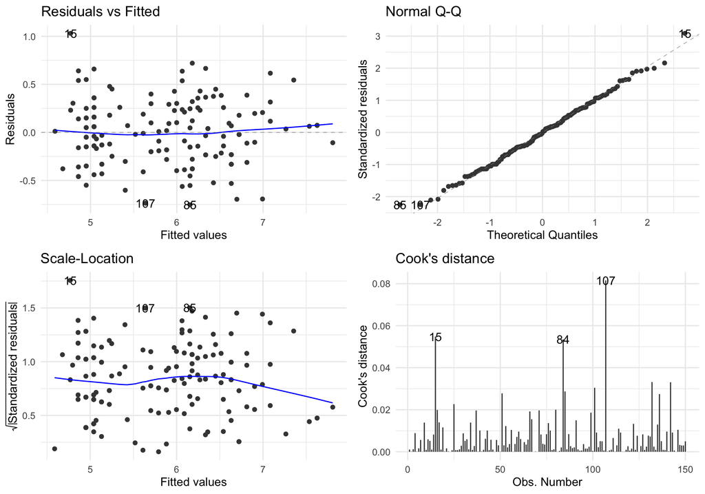

**Code**

```r
autoplot(ancova_add, which = 1:4, ncol = 2) +
  theme_minimal(base_size = 12)
```

## Key Takeaways: ANCOVA

**Summary**

1. ANCOVA combines a **continuous covariate** with a **categorical factor** in a single linear model
2. The **additive model** (`y ~ x + group`) fits parallel lines; the **interaction model** (`y ~ x * group`) allows different slopes
3. Use `anova()` to compare nested models and decide whether the interaction is needed
4. Use **Type II SS** (`car::Anova()`) to test each term after accounting for the others
5. Use **emmeans** for post-hoc comparisons — the adjusted means account for the covariate
6. Always check diagnostics — the assumptions are the same as linear regression (linearity, normality, constant variance) plus **homogeneity of regression slopes** for the additive model